# BIOS 611 HW1 Data visualisation (Chapter 3)

# Exercise 3

1. What geom would you use to draw a line chart? A boxplot? A histogram? An area chart?

   Answer:

   `Geom_line` is used to draw a line chart. `Geom_boxplot` is used to draw a boxplot. `Geom_histogram` is used to draw a histogram. `Geom_area` is used to draw an area chart.
2. Run this code in your head and predict what the output will look like. Then, run the code in R and check your predictions.

   ```r
   ggplot(data = mpg, mapping = aes(x = displ, y = hwy, color = drv)) +
     geom_point() +
     geom_smooth(se = FALSE)
   ```

   Answer:

   I think the code is going to provide a plot with points between `displ` and `hwy`, with different categories of `drv`. And smoothed lines between `displ` and `hwy` is shown on the plot, categorized by `drv`, but without shaded area.
3. What does `show.legend = FALSE` do? What happens if you remove it?  
   Why do you think I used it earlier in the chapter?

   Answer:

   The `show.legend = FALSE` will suppress the legend of the variable. If removed, the legend is shown on the right of the plot. This is because the `drv` has few categories.
4. What does the `se` argument to `geom_smooth()` do?

   Answer:

   The `se` argument will show or suppress the shaded area of the line.
5. Will these two graphs look different? Why/why not?

   ```r
   ggplot(data = mpg, mapping = aes(x = displ, y = hwy)) +
     geom_point() +
     geom_smooth()

   ggplot() +
     geom_point(data = mpg, mapping = aes(x = displ, y = hwy)) +
     geom_smooth(data = mpg, mapping = aes(x = displ, y = hwy))
   ```

   Answer:

   The two graphs will look same.

   For first plot, it uses `mpg` dataset, and maps `displ` and `hwy`. `geom_point()` draws all points between `displ` and `hwy`. `geom_smooth()` draws a smoothed line between `displ` and `hwy`.

   For second plot, `geom_point` uses `mpg` dataset, and draws all points between `displ` and `hwy`. `geom_smooth` uses `mpg` dataset, and draws a smoothed line between `displ` and `hwy`.
6. Recreate the R code necessary to generate the following graphs.

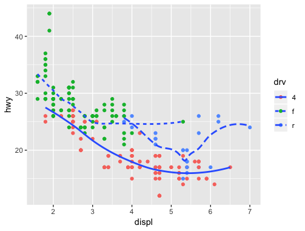

   Smooth lines for each `drv`

   Answer:

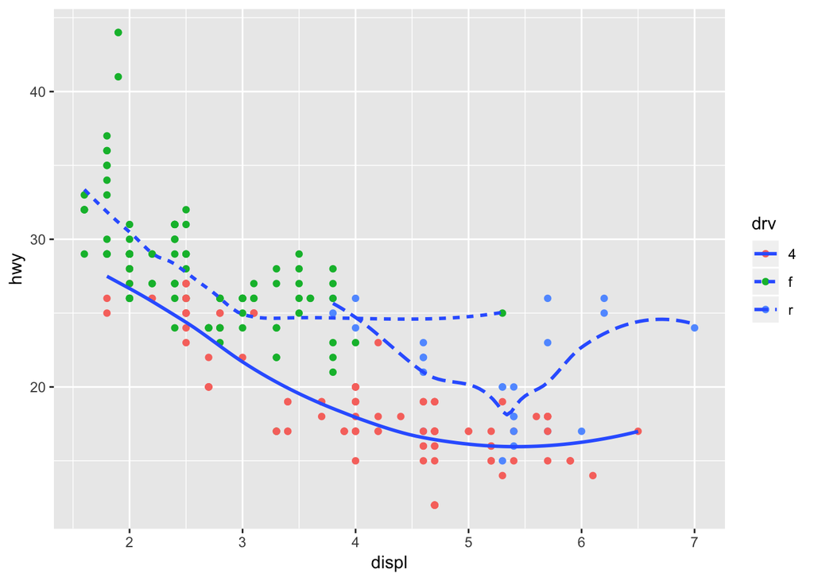

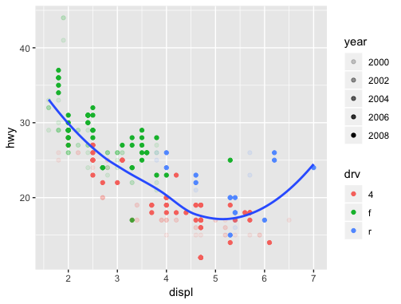

   A single smooth line, transparency by `year`

   Answer:

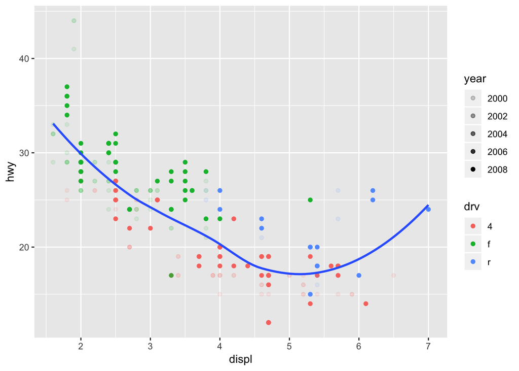

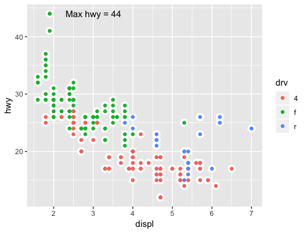

   Layered dots and an additional text information

   Adding texts was not covered in class, but give it a try!

   Answer:

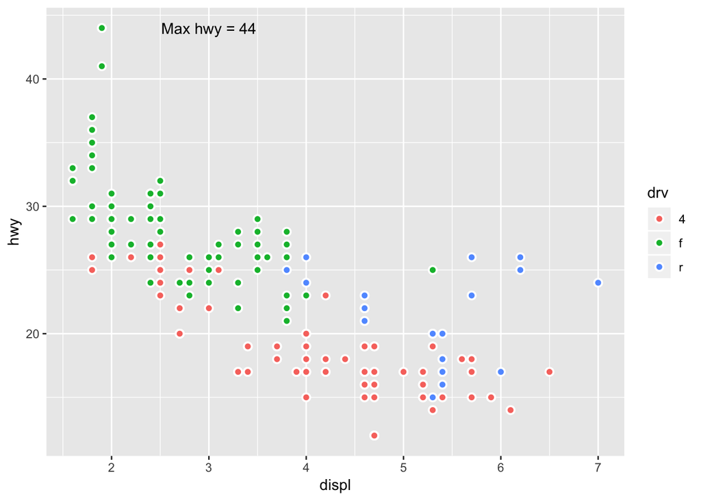

   ```r
   ggplot(data = mpg, mapping = aes(x = displ, y = hwy)) +
     geom_point(mapping = aes(fill = drv), color = "White", shape = 21, size = 2,  stroke = 1) + annotate("text", x = 3, y = 44, label = "Max hwy = 44")
   ```

# Exercise 4

1. What is the default geom associated with `stat_summary()`? How could you rewrite the previous plot to use that geom function instead of the stat function?

   Answer:

   The default geom is `summary`.

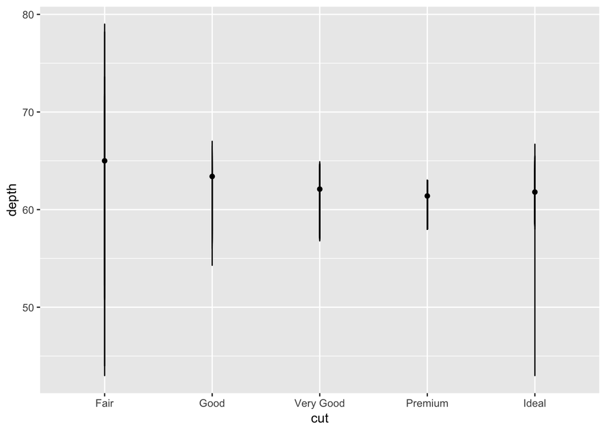

   ```r
   ggplot(data = diamonds, mapping = aes(x = cut, y = depth)) +
     geom_line() +
     geom_point(stat = "summary", fun.y = median)
   ```

2. What does `geom_col()` do? How is it different to `geom_bar()`?

   Answer:

   `geom_col()` uses the height of bars to show the actual value of data. `geom_bar()` uses height to represent the count in each group.
3. What variables does `stat_smooth()` compute? What parameters control its behaviour?

   Answer:

   `stat_smooth` smooth the density of continuous variables. `method`, `formula`, `se`, `fullrange`, `level` control its behavior.

# Exercise 5

1. What is the problem with this plot? How could you improve it?

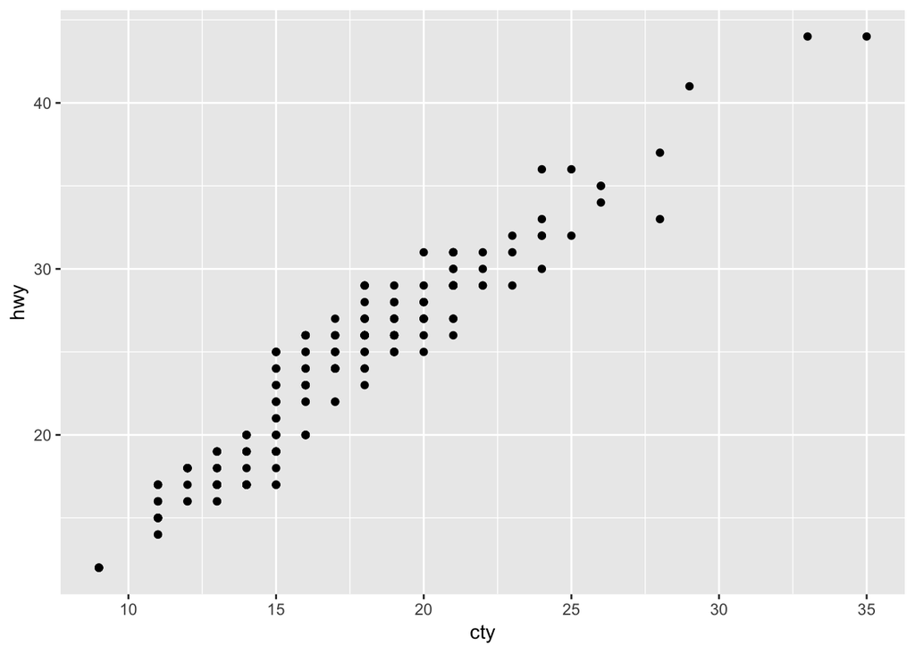

   ```r
   ggplot(data = mpg, mapping = aes(x = cty, y = hwy)) +
     geom_point()
   ```

   Answer:

   Many points are overlapping.

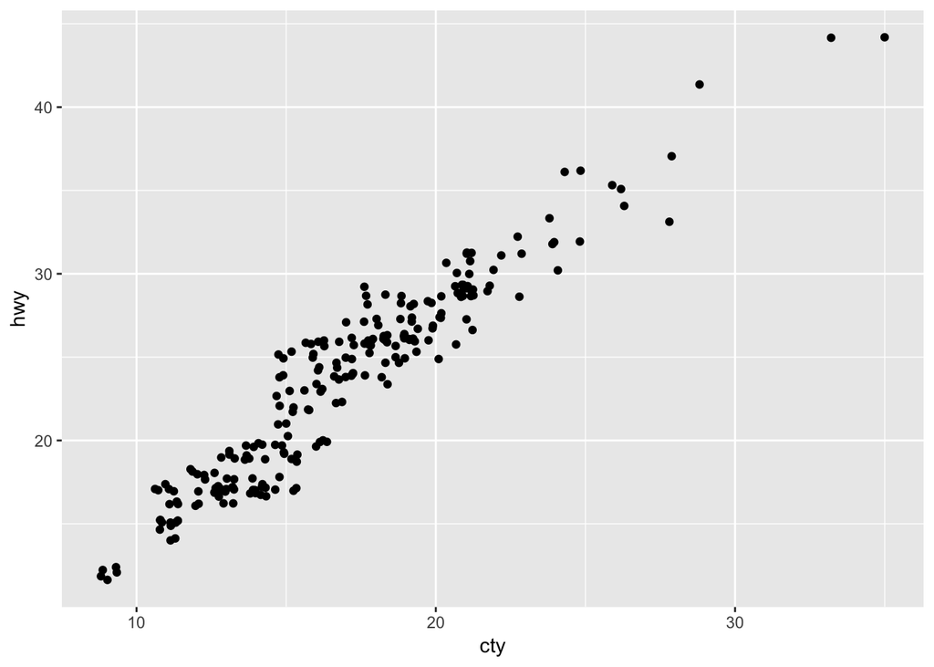

   ```r
   ggplot(data = mpg, mapping = aes(x = cty, y = hwy)) +
     geom_point(position = 'jitter')
   ```

2. What parameters to `geom_jitter()` control the amount of jittering?

   Answer:

   `width` and `height` controls the amount of jittering.
3. Compare and contrast `geom_jitter()` with `geom_count()`.

   Answer:

   Similar: Two functions both draw and display all points between two variables. Difference: `geom_jitter()` displays all points with same size. `geom_count()` displays points with distinct sizes, which is number of cases around each point.

# Exercise 6

1. Turn a stacked bar chart into a pie chart using `coord_polar()`.

   Answer:

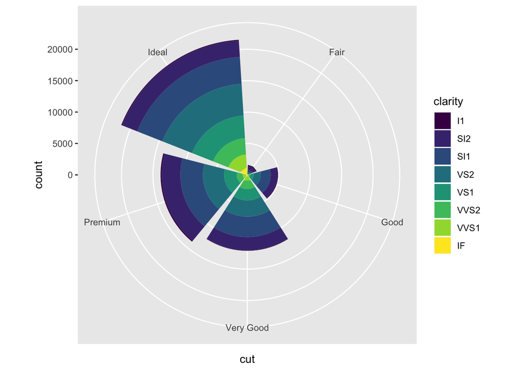

   ```r
   ggplot(data = diamonds) +
     geom_bar(mapping = aes(x = cut, fill = clarity)) +
     coord_polar()
   ```

2. What does `labs()` do? Read the documentation.

   Answer:

   `labs()` uses new labels to display variables.
3. What does the plot below tell you about the relationship between city and highway mpg? Why is `coord_fixed()` important? What does `geom_abline()` do?

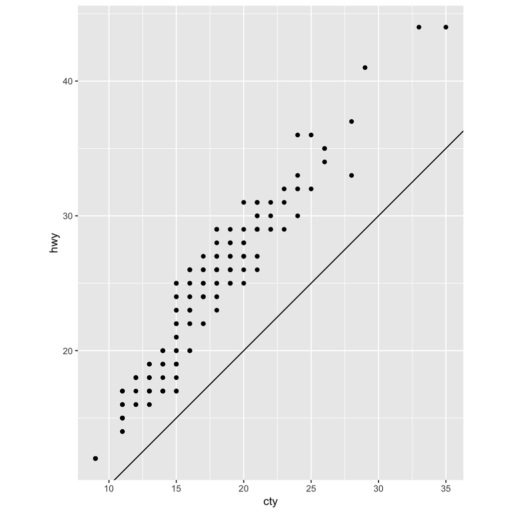

   ```r
   ggplot(data = mpg, mapping = aes(x = cty, y = hwy)) +
     geom_point() +
     geom_abline() +
     coord_fixed()
   ```

   Answer:

   There is positive relationship between `cty` and `hwy`. When `cty` is higher, `hwy` tends to be higher.

   `coord_fixed()` will fix the ratio between units on the x axis and y axis. Otherwise, the plot will look like a flat.